# Results: Plots - Generator upper bound sets

2024-05-02

Testsets

- set_options = [‘l’,‘m’,‘u’] - three different levels of nonsupported points.
- seed_options = [1,2,3,4,5]
- size_options = [10,50,100,150, 200] [300, 600]
- UB_options = [‘lexmin’,‘extreme’,‘0.25’,‘0.5’,‘0.75’,‘all’]

Note:

- All sets are in p=2 dimensions.
- For each test the sets $Y^1$ and $Y^2$ are ‘scaled’ the same.

## Statistics for the problems solved using alg3

Testsets

- In each testset $|Y^1| = |Y^2|$

Given a problem consisting of $2$ subproblems $Y^1$, $Y^2$ and a level of $Y^2$, we find a generator upper bound of $Y^2$ based on the points of $Y^1$ and a subset of $Y^2$ (based on some level). Steps: 1. For each testset do: 2. Define subset of $Y^2$ based on ub_level - Here we use all extreme points of $Y^2$. 3. Define generator upper bound of the set $Y^2$using the sets $Y^2$ and subset of $Y^2$. 4. Determine the points of $Y^2$which are dominated by the generator upper bound set. 5. Record the number of dominated points along with the time spent calculating the generator upper bound set.

The following grid shows an example of the number of dominated points. [size = 100, ub_option = ‘extreme’]

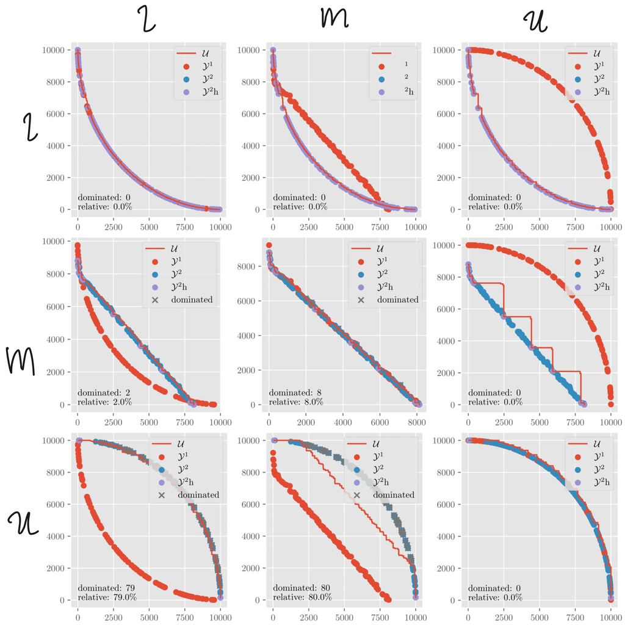

Example of instances

In the following we plot the relative number of points dominated by the generator upper bound set. We plot this in a grid for different levels of nonsupported points. In each plot we present boxplots for several sizes of the input sets.

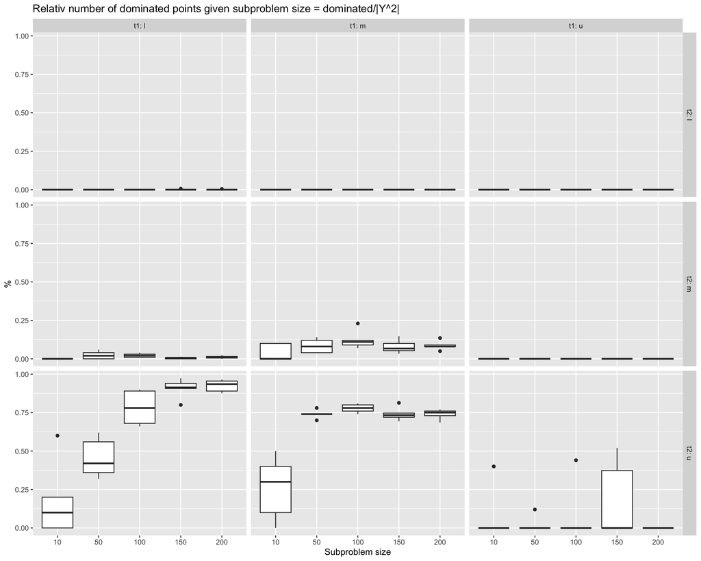

Results: “The more #nonsupported points the more points are dominated by a generator upper bound set”

## In the following we evaluate different levels of partial sets Y2 used for the generator upper bound set

- UB_options = [‘lexmin’,‘extreme’,‘0.25’,‘0.5’,‘0.75’,‘all’]

In the following we consider the case where only a subset of $Y^2$is used to define a generator upper bound set. We look at different levels of partial sets $\hat{Y}^2$ defined as follows:

- ‘lexmin’ $\Rightarrow$ $\hat{Y}^2$ consists of only the lexmin solutions.
- ‘extreme’ $\Rightarrow$ $\hat{Y}^2$ consists of only all extreme supported points.
- ‘x%’ $\Rightarrow$ $\hat{Y}^2$ consists of all extreme supported points plus x% of the remaining points (eg. for x= 0.25 $ ^2 = Y^2_{se} $ 25% of the remaining points chosen in lex-order).
- ‘all’ $\Rightarrow$ $\hat{Y}^2$ =$Y^2$

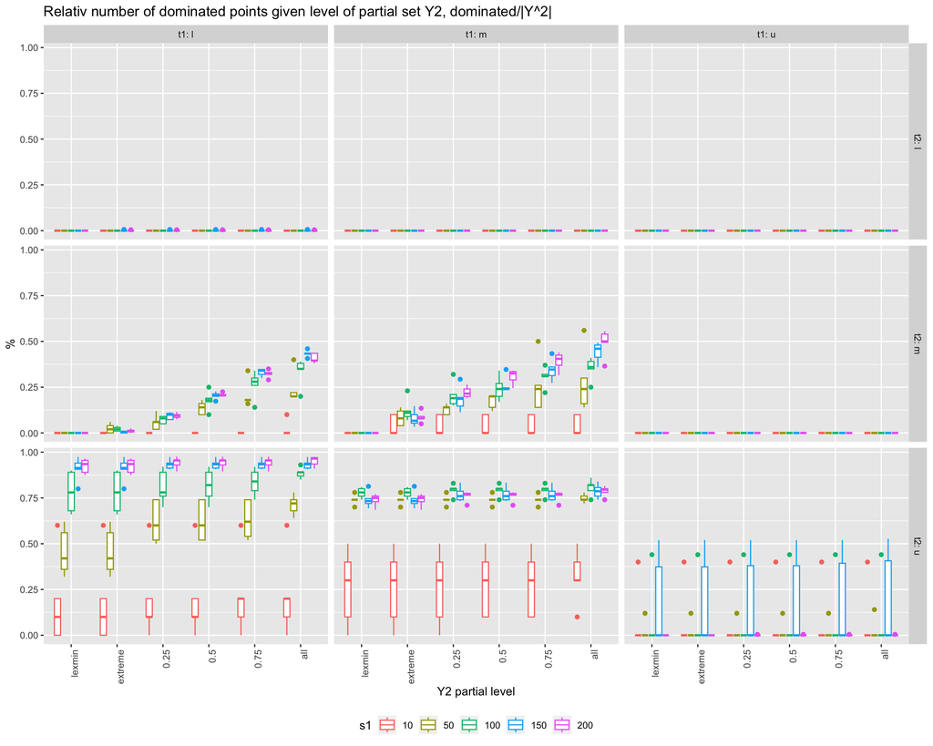

In the following we show how long is spent calculating the generator upper bound sets

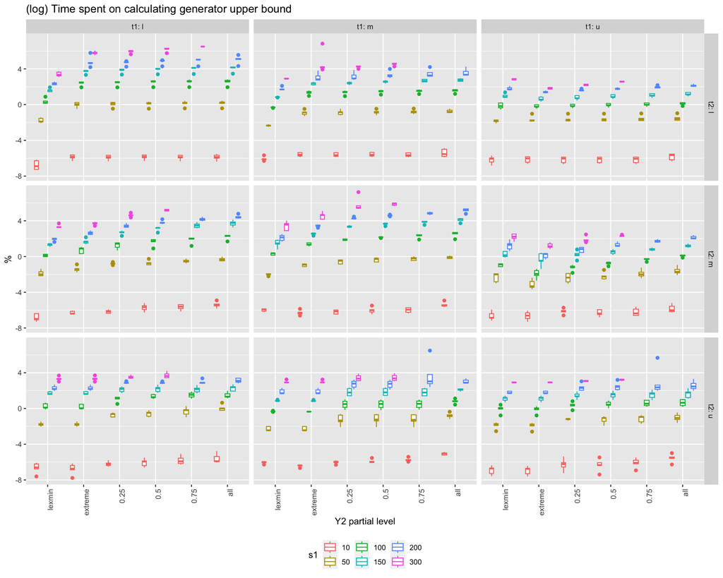

# The algorithm used to find the generator upper bound set

- From report 6860
- Only works for $p=2$ Notation: Opposite use of $Y^1$ and $Y^2$ with respect to the above.

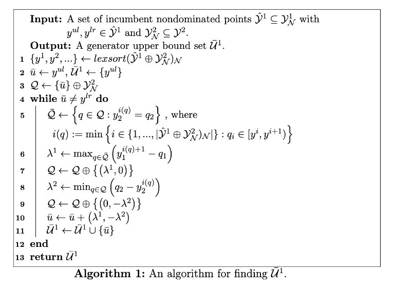

Generator upper bound algorithm

Example of algorithm run:

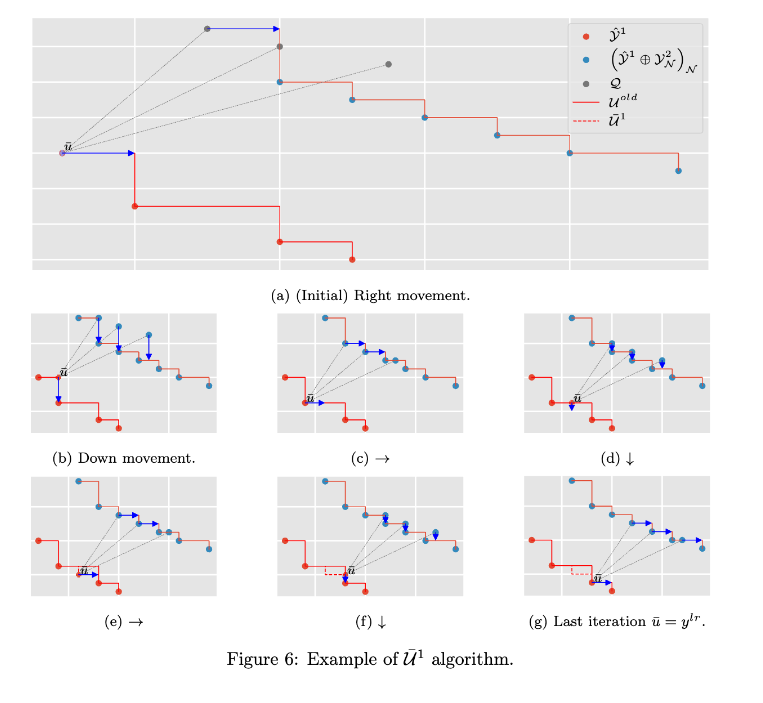

Example generator upper bound algorithm